# PSL (F20) Project 3

Vijayakumar Sitha Mohan (VS24), Waitong Matthew Leung (wmleung2)

15-Nov-2020

## Introduction

We are provided with a dataset consisting of 50,000 IMDB movie reviews, where each review is labelled as positive or negative. The goal is to build a binary classification model to predict the sentiment of a movie review.

One crucial step of building this binary classification model is to extract a set of vocabulary so we can use it to convert each review into a DT (DocumentTerm) matrix before fitting in classification model. This R mark down document is focused on how to come up with the set of vocabulary.

## Prepare for training/test splits

Generate the five sets of training/test splits with each set (3 files: train.tsv, test.tsv, test_y.tsv) stored in a subfolder.

## Construction of vocabulary

### Define stop words and filter them out of our movie reviews

We define a set of stop words are the words that doesn’t not have information for our classification task. We will filter them out first.

“i”, “me”, “my”, “myself”, “we”, “our”, “ours”, “ourselves”, “you”, “your”, “yours”, “their”, “they”, “his”, “her”, “she”, “he”, “a”, “an”, “and”,“is”, “was”, “are”, “were”, “him”, “himself”, “has”, “have”, “who”,“when”,“where”,“why”,“it”, “its”, “the”, “us”

### Construct DT (DocumentTerm) matrix

Construct DT (Document Term) matrix (maximum 4-grams) by using ‘text2vec’ R package.

- HTML tags are removed from the movie review first
- We define stem tokenizer using SnowballC::wordStem() to tokenize movie review in stem form of word, e.g. stem word of both “winning” and “winner” has stem word of “win”
- build vocab list by stem tokenizer with maximum 4-grams
- prune vocab list by only taking term count minimal of 10, and filter out terms that has too high or too low proportion of documents which contain the term.
- The resulting vocab size is 30K+ which is the number of columns in DT matrix.
- We used custom stop_words instead of stop_words available in the tm package. If we use we lose many words and wouldn’t able to meet the benchmark.

#### Method 1 : trim vocab size to 2K by Lasso

The glmnet output contains many sets of estimated beta values corresponding to different lambda values. In particular, “$df” tells us the number of non-zero beta values (i.e., df) for each of the estimates. We picked the largest df among those less than 2K, and store the corresponding words in “myvocab”.

We rebuild DT matrix with LASSO reduced 2000 vocab. However, we find some these LASSO reduced vocab is not quite interpretable, e.g. “ryan”, “fulci”, “jimmi_stewart”. We will try another method to find more interpretable vocab list.

#### Method 2 : two-sample t-test

Method 2 to extract top 2K more interpretable vocab by two-sample t-test (store in myvocab2). We use the original DT matrix with 30K+ columns as input.

- compute two-sample t-statistic of two population X and Y to determine the chance of have same mean for each 30K+ columns

t-statistics = $\frac{\bar{X} - \bar{Y}}{(s_x^2/m + s_y^2/n)^{0.5}}$

- order words by the magnitude of their t-statistics and picked the top 2000 words, which are then divided into two lists: top 1000 positive words and top 1000 negative words.

#### Top 10 Positive and Negative Words

| Positive_Words | Negative_Words |
| --- | --- |
| great | bad |
| excel | worst |
| love | wast |
| best | aw |
| perfect | poor |
| of_best | bore |
| beauti | terribl |
| one_of_best | stupid |
| brilliant | wors |
| high_recommend | horribl |

#### Comparison of selected Positive and Negative words in WordCloud

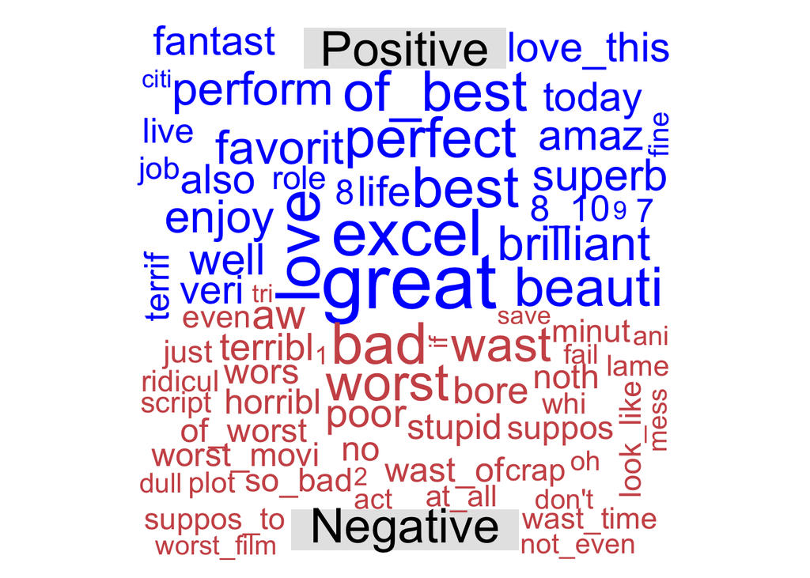

- Reconstruct DT matrix with the new 2K more interpretable vocabs with maximum 3-grams. We notice 2-grams is not enough to represent the true sentiment in some cases, e.g. watch_this in 2-grams means totally opposite in not_watch_this in 3-grams.
- Trim 2K vocab to 1K by LASSO and store it to myvocab2
- This final 1K vocab list is more interpretable. There are no names in the list. We will use this to train Ridge logistic regression model

## Train Ridge logistic regression model by using 1K interpretable vocabulary words

- use cross validation to find optimal lambda using cv.glmnet()
- train Ridge logistic model with the 1K vocab DT matrix with optimal lambda value

## Test AUC on all 5 splits

| Split | Test_AUC |
| --- | --- |
| 1 | 0.9713 |
| 2 | 0.9708 |
| 3 | 0.9704 |
| 4 | 0.9706 |
| 5 | 0.9698 |

#### Running time: System: MSI laptop, Intel i5, 2.0GHz, 8GB, Win 10

| Run.Time.Test | Run.Time.Train |
| --- | --- |
| 44.12 secs | 2.287 mins |